# Toolbox Demo: Samoa

# 1 Overview

To get some hands-on experience with the Toolbox, we will explore how Ocean Health Index (OHI) scores respond when add different data to the LSP goal.

You will be using the OHI Toolbox software to do this, and follow the instructions here ([`workshop-toolbox.Rmd`](http://ohi-science.org/sam/workshop-toolbox)). We will walk through line-by-line together and execute the code in R; the order does matter so be sure to proceed line-by-line.

Your final figures will be saved as .pngs within the `sam` folder you downloaded: `sam/toolbox-demo/reports/figures`.

## 1.1 Get the `sam` repository

We’ll be playing with the Toolbox for the global OHI assessments; we calculate scores each year for 220 coastal nations and territories. We have copied this into a GitHub repository called `sam` for Samoa. Let’s get it on your computer.

1. Go to github.com/OHI-Science/sam. This is the `sam` repository (called ‘repo’).
2. Click on the green ‘clone or download’ button.
3. Clone or download somewhere you can find on your computer. If you are familiar with GitHub, clone this repository. Otherwise click ‘Download ZIP’.
4. Navigate to where you saved the `sam` repo on your computer and rename it to `sam` if it has any other name. Double-click the `sam.Rproj` file. This will open [RStudio](https://www.rstudio.com/) (which is how you should always interface with R).
5. Within the RStudio file directory pane (bottom right), navigate to the `toolbox-demo` folder. Inside is a mix of `.R` scripts and `.csv` files. We will just focus on a few of them.

## 1.2 Setup

Since we’re in RStudio with a `.Rproj` file, our current working directory is `wherever/you/saved/it/sam`. All of our work in the Toolbox happens in the `toolbox-demo` folder within the `sam` folder. (Even [these instructions](https://github.com/OHI-Science/sam/blob/master/toolbox-demo/workshop-toolbox.Rmd) are within the `toolbox-demo` folder!) But we need to let R know that we want to be working inside the `toolbox-demo` folder. Let’s change the working directory to the `toolbox-demo` folder, and install the packages we need to get going.

Run the following code:

```r
## set working directory to sam/toolbox-demo with setwd()
setwd('toolbox-demo')

## install the packages we need.

## tidyverse is by RStudio, for "data wrangling"
install.packages("tidyverse")
library(tidyverse)

## devtools helps install our ohicore software
install.packages('devtools') # do this just one time!
library(devtools) # do this every time you begin

devtools::install_github("ohi-science/ohicore@dev") # do this just one time!
library(ohicore) # do this every time you begin

## source the function to make flower plots; this won't do anything yet, but it makes it available to us.
source('plot_flower_local.r')
```

There are 220 countries that will be in our data set below, and we will just want to change information for Samoa. Samoa’s region identifier number is 152 (full list [here](https://github.com/OHI-Science/sam/blob/master/toolbox-demo/layers/rgn_global.csv)).

```r
## identify region identifier for Samoa
rgn_id_sam <- 152
```

## 1.3 LSP’s new data

### 1.3.1 Import and view

First read in new data. In this example we have saved the new WDPA data from May 2018 in a folder called workshop-data.

The data is already tidy!

```r
wdpa <- read_csv("workshop-data/WDPA_May2018.csv")
wdpa %>%
  select(NAME, REP_M_AREA, STATUS, STATUS_YR, NO_TK_AREA)
```

```
## # A tibble: 6 x 5
##   NAME         REP_M_AREA STATUS     STATUS_YR NO_TK_AREA
##   <chr>             <dbl> <chr>          <int>      <int>
## 1 Ava o sina       0.0100 Designated      1999          0
## 2 punaoa           0.0700 Designated      1999          0
## 3 Afaga Tele       0.510  Designated      1999          0
## 4 Vaiee            0.770  Designated      1999          0
## 5 Fausaga          0.280  Designated      1999          0
## 6 Faaofi laulu     0.200  Designated      1999          0
```

### 1.3.2 Transform

Summarize the total areas within MPAs:

```r
mpa_area_total <- wdpa %>%
  group_by(STATUS_YR) %>%
  mutate(AREA_KM2 = sum(REP_M_AREA)) %>%
  select(NAME, REP_M_AREA, STATUS, STATUS_YR, NO_TK_AREA, AREA_KM2)
mpa_area_total
```

```
## # A tibble: 6 x 6
## # Groups:   STATUS_YR [1]
##   NAME         REP_M_AREA STATUS     STATUS_YR NO_TK_AREA AREA_KM2
##   <chr>             <dbl> <chr>          <int>      <int>    <dbl>
## 1 Ava o sina       0.0100 Designated      1999          0     1.84
## 2 punaoa           0.0700 Designated      1999          0     1.84
## 3 Afaga Tele       0.510  Designated      1999          0     1.84
## 4 Vaiee            0.770  Designated      1999          0     1.84
## 5 Fausaga          0.280  Designated      1999          0     1.84
## 6 Faaofi laulu     0.200  Designated      1999          0     1.84
```

```r
mpa_area_total_sam <- unique(mpa_area_total$AREA_KM2)
```

So since all were designated in the same year, 1.84 is the total recorded since 1999.

### 1.3.3 Current Toolbox Data

Inspect LSP data layer that already exists:

```r
lsp_prot_area_offshore3nm <- read_csv("layers/lsp_prot_area_offshore3nm.csv")
## display
lsp_prot_area_offshore3nm  %>%
  filter(rgn_id == rgn_id_sam)
```

```
## # A tibble: 18 x 3
##    rgn_id  year a_prot_3nm
##     <int> <int>      <dbl>
##  1    152  2000       1.84
##  2    152  2001       1.84
##  3    152  2002       1.84
##  4    152  2003       1.84
##  5    152  2004       1.84
##  6    152  2005       1.84
##  7    152  2006       1.84
##  8    152  2007       1.84
##  9    152  2008       1.84
## 10    152  2009       1.84
## 11    152  2010       1.84
## 12    152  2011       1.84
## 13    152  2012       1.84
## 14    152  2013       1.84
## 15    152  2014       1.84
## 16    152  2015       1.84
## 17    152  2016       1.84
## 18    152  2017       1.84
```

Since the WDPA data shows that all were designated in 1999, and the OHI LSP data layer begins with 2000, we can inject 1.84 for all years.

### 1.3.4 Substitute new data

Inject in LSP data layer.

```r
## base-R
# lsp_prot_area_offshore3nm$a_prot_3nm[lsp_prot_area_offshore3nm$rgn_id == rgn_id_sam] <- mpa_area_total_sam

## tidyverse
lsp_new <- rbind(
  lsp_prot_area_offshore3nm %>%
    filter(rgn_id != rgn_id_sam),
  lsp_prot_area_offshore3nm %>%
    filter(rgn_id == rgn_id_sam) %>%
    mutate(a_prot_3nm = mpa_area_total_sam)) %>%
  arrange(rgn_id, year)

## save new data in existing layer
write_csv(lsp_new, "layers/lsp_prot_area_offshore3nm.csv")
```

We can check in the differences in GitHub and see that Samoa’s data have been updated.

### 1.3.5 Recalculate scores

```r
source("calculate_scores.R")
```

[output not shown]

[output cut: 63 more lines]

[output not shown]

```
## Unused fields...
##     le_rev_sector_year: analysis_year
##     ico_spp_iucn_status: iucn_sid
##     le_jobs_sector_year: analysis_year
##     le_wage_sector_year: analysis_year
```

```
## Rows duplicated...
##     le_rev_sector_year: 3272
##     ico_spp_iucn_status: 8738
##     le_jobs_sector_year: 2174
##     le_wage_sector_year: 546
```

```
## Layers missing data, ie all NA ...
##     element_wts_cp_km2_x_protection: element_wts_cp_km2_x_protection.csv
##     element_wts_cs_km2_x_storage: element_wts_cs_km2_x_storage.csv
##     element_wts_hab_pres_abs: element_wts_hab_pres_abs.csv
```

```
## Layer element_wts_cp_km2_x_protection has no rows of data.
```

```
## Layer element_wts_cs_km2_x_storage has no rows of data.
```

```
## Layer element_wts_hab_pres_abs has no rows of data.
```

```
## Calculating Status and Trend for each region for FIS...
## Calculating Status and Trend for each region for MAR...
## Calculating Status and Trend for each region for AO...
## Calculating Status and Trend for each region for NP...
## Calculating Status and Trend for each region for CS...
## Calculating Status and Trend for each region for CP...
## Calculating Status and Trend for each region for TR...
## Calculating Status and Trend for each region for LIV...
## Calculating Status and Trend for each region for ECO...
```

```
##
##   data values are NA so removed: 6 of 185 rows
```

```
## Calculating Status and Trend for each region for ICO...
## Calculating Status and Trend for each region for LSP...
## Calculating Status and Trend for each region for CW...
## Calculating Status and Trend for each region for HAB...
```

```
## Calculating Status and Trend for each region for SPP...
## Calculating Pressures for each region...
## There are 6 pressures subcategories: pollution, alien_species, habitat_destruction, fishing_pressure, climate_change, social
```

```
## These goal-elements are in the weighting data layers, but not included in the pressure_matrix.csv:
## LIV-aqf, ECO-ph, ECO-sb, ECO-tran
```

```
## Calculating Resilience for each region...
## There are 7 Resilience subcategories: ecological, alien_species, goal, fishing_pressure, habitat_destruction, pollution, social
## Calculating Goal Score and Likely Future for each region for FIS...
## Calculating Goal Score and Likely Future for each region for MAR...
## Calculating Goal Score and Likely Future for each region for AO...
## Calculating Goal Score and Likely Future for each region for NP...
## Calculating Goal Score and Likely Future for each region for CS...
## Calculating Goal Score and Likely Future for each region for CP...
## Calculating Goal Score and Likely Future for each region for TR...
## Calculating Goal Score and Likely Future for each region for LIV...
## Calculating Goal Score and Likely Future for each region for ECO...
## Calculating Goal Score and Likely Future for each region for ICO...
## Calculating Goal Score and Likely Future for each region for LSP...
## Calculating Goal Score and Likely Future for each region for CW...
## Calculating Goal Score and Likely Future for each region for HAB...
## Calculating Goal Score and Likely Future for each region for SPP...
## Calculating post-Index function for each region for FP...
```

```
## Calculating post-Index function for each region for LE...
## Calculating post-Index function for each region for SP...
## Calculating post-Index function for each region for BD...
## Calculating Index Score for each region using goal weights to combine goal scores...
## Calculating Index Likely Future State for each region...
## Calculating Post-process PreGlobalScores() function for each region...
## Calculating scores for ASSESSMENT AREA (region_id=0) by area weighting...
## Calculating FinalizeScores function...
```

```
## Using layers/fp_wildcaught_weight.csv to plot FIS and MAR with unequal weighting
```

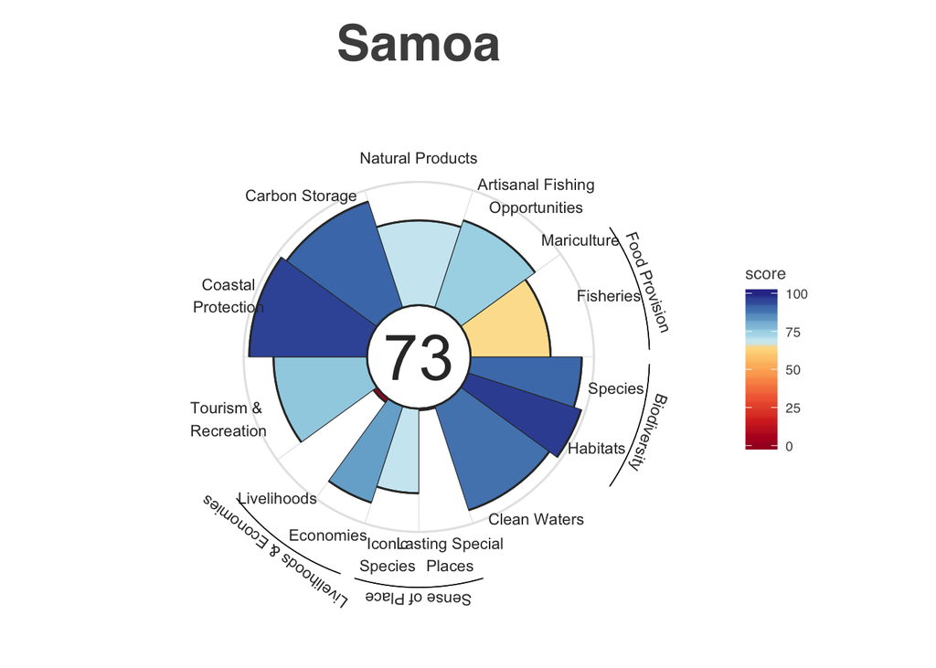

```r
# visualize scores ----

## Flower plots for each region ----
source('plot_flower_local.R')

##  plot.
PlotFlower(region_plot = rgn_id_sam,
  assessment_name = "Samoa",
  dir_fig_save = "reports/figures/flower_new")
```

Inspect new scores. The best way to do this is by looking at the GitHub differences in scores.csv and in the flower plot.

In this example, the change is too small to be visible in the flower plot, but that is what we would expect from such a small change in data. And LSP is just one goal.

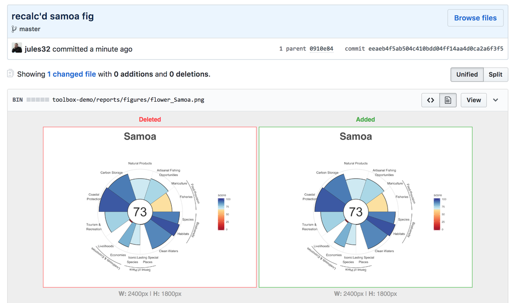

We can also look at the scores in R:

```r
scores <- read_csv("scores.csv")
scores %>%
  filter(region_id == rgn_id_sam,
         goal == "LSP")
```

```
## # A tibble: 6 x 4
##   goal  dimension  region_id score
##   <chr> <chr>          <int> <dbl>
## 1 LSP   future           152  1.31
## 2 LSP   pressures        152 33.0
## 3 LSP   resilience       152 76.7
## 4 LSP   score            152  1.23
## 5 LSP   status           152  1.15
## 6 LSP   trend            152  0.
```